# Izmir’s Fish Market Prices

Mine Kara

December 11, 2021

# Introduction

## Dataset Structure

[*Here*](https://openfiles.izmir.bel.tr/100160/docs/balik_hal_fiyatlari.csv) is the dataset analyzed in this report.

This report is about Izmir’s Fish Market prices.

```r
raw_df <- read.csv("https://raw.githubusercontent.com/MineKara95/R/main/balik_hal_fiyatlari.csv",stringsAsFactors = FALSE, header = TRUE, sep = ";", encoding="UTF-8")

fish_market <- raw_df %>%
  select(date = "TARIH", product_type = "MAL_TURU", product_name = "MAL_ADI", units = "BIRIM", min_price = "ASGARI_UCRET", max_price = "AZAMI_UCRET") %>%
  mutate(month = lubridate::month(date, label = TRUE))

str(fish_market)
```

```
## 'data.frame':    18369 obs. of  7 variables:
##  $ date        : chr  "2021-01-02 00:00:00" "2021-01-02 00:00:00" "2021-01-02 00:00:00" "2021-01-02 00:00:00" ...
##  $ product_type: chr  "BALIK" "BALIK" "BALIK" "BALIK" ...
##  $ product_name: chr  "TIRSI (DENİZ)" "KIRLANGIÇ (DENİZ)" "ÇİMÇİM (DENİZ)" "HANOS ( DENİZ )" ...
##  $ units       : chr  "KG" "KG" "KG" "KG" ...
##  $ min_price   : num  5.83 3 3.5 2.5 45 130 38 25 10 2.5 ...
##  $ max_price   : num  12.5 80 8 5 45 130 38 55 10 6.67 ...
##  $ month       : Ord.factor w/ 12 levels "Jan"<"Feb"<"Mar"<..: 1 1 1 1 1 1 1 1 1 1 ...
```

As you can see above, this dataset includes date, product types, product names, unit, minimum price and maximum price of these product. Also, there are 18,369 observations in the dataset.

## Null Values

It is determined whether null values exist in the dataset. As we can see here is that our dataset has no null values. Thus, we do not need to drop or replace any values.

```r
head(is.na(fish_market))
```

```
##       date product_type product_name units min_price max_price month
## [1,] FALSE        FALSE        FALSE FALSE     FALSE     FALSE FALSE
## [2,] FALSE        FALSE        FALSE FALSE     FALSE     FALSE FALSE
## [3,] FALSE        FALSE        FALSE FALSE     FALSE     FALSE FALSE
## [4,] FALSE        FALSE        FALSE FALSE     FALSE     FALSE FALSE
## [5,] FALSE        FALSE        FALSE FALSE     FALSE     FALSE FALSE
## [6,] FALSE        FALSE        FALSE FALSE     FALSE     FALSE FALSE
```

```r
sum(is.na(fish_market))
```

```
## [1] 0
```

## Number of Unique Fishes

There are 4 types of product and 126 unique seafood.

```r
unique(fish_market[c("product_type")])
```

```
##     product_type
## 1          BALIK
## 8         KÜLTÜR
## 42 İTHAL (DONUK)
## 43      TATLI SU
```

```r
count(unique(fish_market[c("product_name")]))
```

```
##     n
## 1 126
```

```r
unique(fish_market$product_name)
```

```
##   [1] "TIRSI (DENİZ)"        "KIRLANGIÇ (DENİZ)"    "ÇİMÇİM (DENİZ)"
##   [4] "HANOS ( DENİZ )"      "KILIÇ (DENİZ)"        "LÜFER ( DENİZ)"
##   [7] "USKUMRU (DENİZ)"      "LEVREK ( KÜLTÜR )"    "KÖPEK (DENİZ)"
##  [10] "ISTAVRIT (DENİZ)"     "IZMARIT (DENİZ)"      "KALAMAR (DENİZ)"
##  [13] "SÜBYE (DENİZ)"        "HAMSI (DENİZ)"        "KOLYOZ (DENİZ)"
##  [16] "LİDAKİ (DENİZ)"       "PALAMUT-TORİK (DENİZ" "KEREVİT ( DENİZ )"
##  [19] "MEZGİT (DENİZ)"       "SOKKAN(DENİZ)"        "BARBUN (TEKİR)"
##  [22] "KOLORİT(DENİZ)"       "DIL"                  "BARBUN(KAYA)"
##  [25] "ÇIPURA (DENİZ)"       "YENGEÇ (DENİZ)"       "SARPA (DENİZ)"
##  [28] "DİL(CANGIDEZ)"        "ÇİPURA ( KÜLTÜR )"    "KARİDES (DENİZ)"
##  [31] "YABANİ KALAMAR"       "MASKO DENİZ"          "PEYGAMBER (DENİZ)"
##  [34] "MERCAN(KÜÇÜK BOY)"    "MERCAN (BÜYÜKBOY)"    "LEVREK (DENİZ)"
##  [37] "YAZILIORKINOS(DENİZ)" "LÜFER (KÜÇÜK )"       "KAMİT(DENİZ)"
##  [40] "BAKALYAR(BÜYÜKBOY)"   "GRANYOZ (DENİZ)"      "ITHAL USKUMRU(DONUK)"
##  [43] "SAZAN ( TATLI )"      "TEKİR(DENİZ)"         "AHTOPOT (DENİZ)"
```

[output cut: 27 more lines]

# Monthly Average Min and Max Price of Product Types

## Monthly Average Min Prices

```r
avg_max_min_price <- fish_market %>% select(date, product_type, product_name, units, min_price, max_price) %>%
group_by(month = lubridate::month(date, label = TRUE), product_type) %>%
summarize(avg_min_price = mean(min_price), avg_max_price = mean(max_price))

avg_max_min_price
```

```
## # A tibble: 40 × 4
## # Groups:   month [10]
##    month product_type  avg_min_price avg_max_price
##    <ord> <chr>                 <dbl>         <dbl>
##  1 Jan   BALIK                  23.9          52.2
##  2 Jan   İTHAL (DONUK)          11.7          17.2
##  3 Jan   KÜLTÜR                 18.3          61.3
##  4 Jan   TATLI SU               24.3          29.8
##  5 Feb   BALIK                  25.5          56.6
##  6 Feb   İTHAL (DONUK)          16.0          22.9
##  7 Feb   KÜLTÜR                 17.6          65.3
##  8 Feb   TATLI SU               26.5          30.8
##  9 Mar   BALIK                  26.6          63.4
## 10 Mar   İTHAL (DONUK)          19.1          24.1
## # … with 30 more rows
```

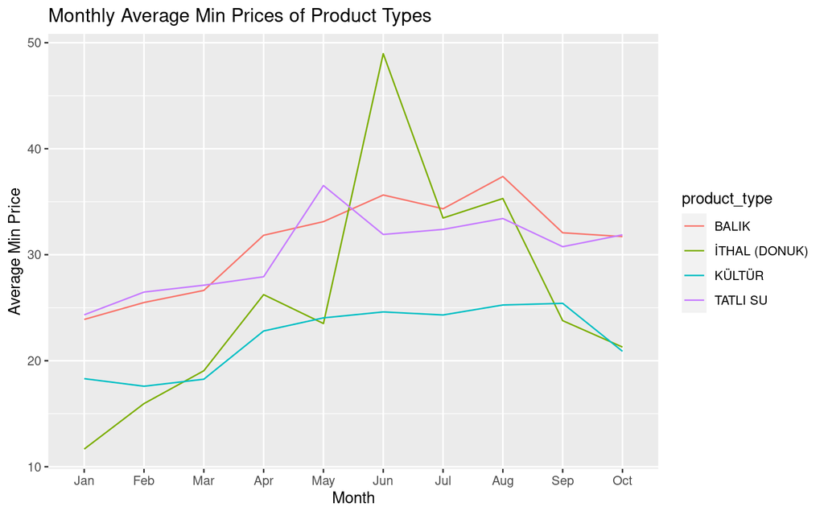

```r
ggplot(avg_max_min_price, aes(month, avg_min_price, group = product_type, color=product_type)) +
  geom_line() +
  labs(x= "Month",
       y = "Average Min Price",
       title = "Monthly Average Min Prices of Product Types")
```

## Monthly Average Max Prices

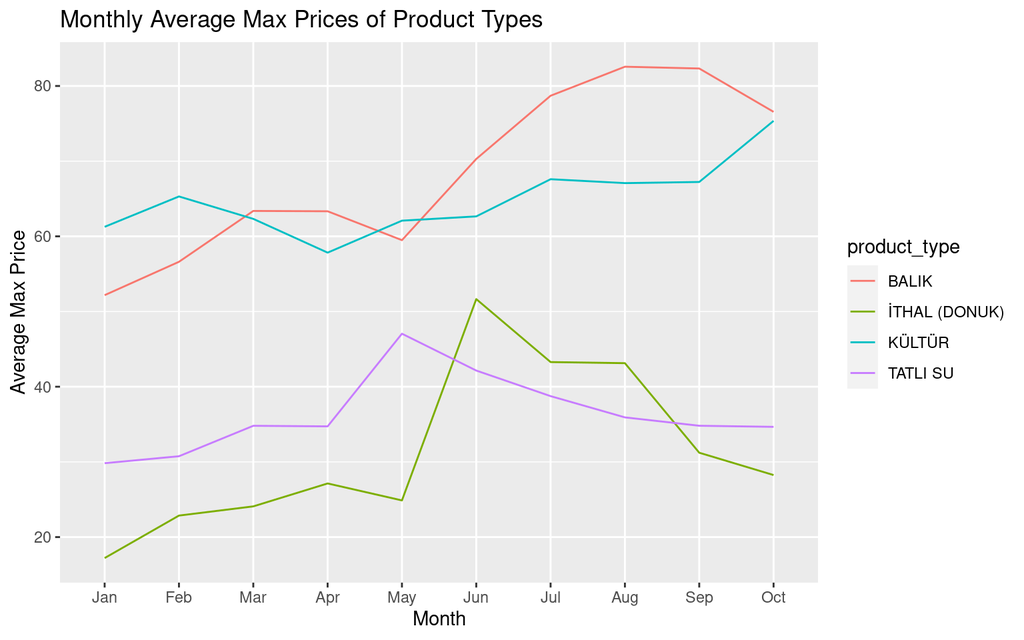

```r
ggplot(avg_max_min_price, aes(month, avg_max_price, group = product_type, color=product_type)) +
  geom_line() +
  labs(x= "Month",
       y = "Average Max Price",
       title = "Monthly Average Max Prices of Product Types")
```

# Monthly Price Difference of Product Types

```r
avg_prices <- avg_max_min_price %>% pivot_longer(c(avg_min_price, avg_max_price), names_to = "average_prices", values_to="values") %>%
  group_by(month, product_type) %>%
  select(month, product_type, average_prices, values)

avg_prices
```

```
## # A tibble: 80 × 4
## # Groups:   month, product_type [40]
##    month product_type  average_prices values
##    <ord> <chr>         <chr>           <dbl>
##  1 Jan   BALIK         avg_min_price    23.9
##  2 Jan   BALIK         avg_max_price    52.2
##  3 Jan   İTHAL (DONUK) avg_min_price    11.7
##  4 Jan   İTHAL (DONUK) avg_max_price    17.2
##  5 Jan   KÜLTÜR        avg_min_price    18.3
##  6 Jan   KÜLTÜR        avg_max_price    61.3
##  7 Jan   TATLI SU      avg_min_price    24.3
##  8 Jan   TATLI SU      avg_max_price    29.8
##  9 Feb   BALIK         avg_min_price    25.5
## 10 Feb   BALIK         avg_max_price    56.6
## # … with 70 more rows
```

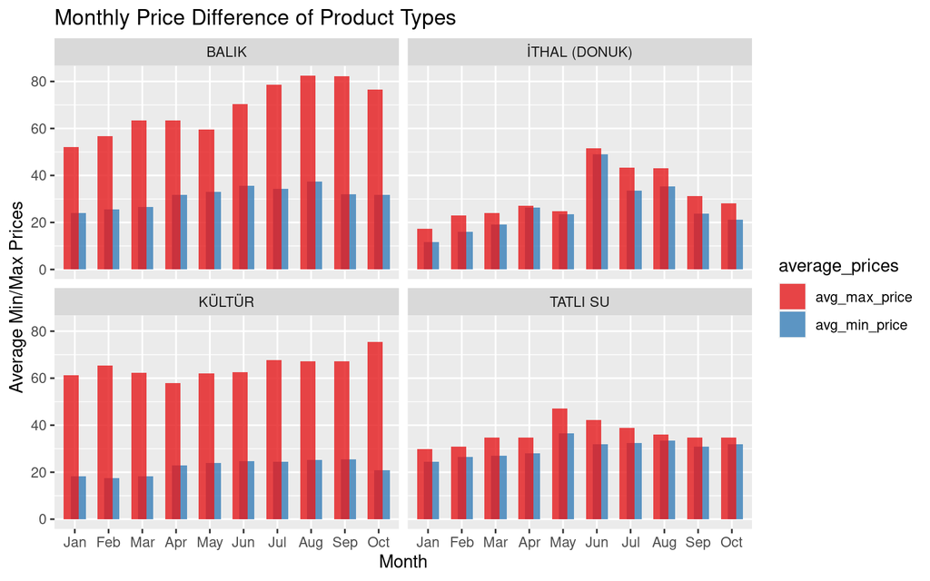

```r
ggplot(avg_prices, aes(month, values, fill=average_prices)) +
  geom_col(position = position_dodge(width = 0.4), alpha = 0.8) +
  scale_fill_brewer(palette = "Set1") +
  labs(x= "Month",
       y = "Average Min/Max Prices",
       title = "Monthly Price Difference of Product Types")+
   facet_wrap(~product_type)
```

The price of “BALIK” and “KÜLTÜR” products is more variable. The difference between max and min price in “BALIK” and “KÜLTÜR” are more.

# Most Expensive Fishes and Their Max Prices

```r
expensive_fishes <- fish_market %>%
  group_by(product_name) %>%
  summarize(max_price = max(max_price)) %>%
  arrange(desc(max_price))

head(expensive_fishes)
```

```
## # A tibble: 6 × 2
##   product_name      max_price
##   <chr>                 <dbl>
## 1 BARBUN (TEKİR)         3500
## 2 İSTAKOZ (DENİZ)         750
## 3 LEVREK (DENİZ)          500
## 4 MERCAN (BÜYÜKBOY)       500
## 5 PEYGAMBER (DENİZ)       500
## 6 KARİDES (DENİZ)         450
```

# Investigating “BARBUN”

We get all types of “BARBUN” data and display their average min and max prices in each month.

```r
barbun_monthly_avg <- fish_market %>%
  filter(str_detect(product_name, "BARBUN")) %>%
  group_by(month, product_name) %>%
  summarize(avg_min_price = mean(min_price), avg_max_price = mean(max_price))

barbun_monthly_avg_pivot <- barbun_monthly_avg %>% pivot_longer(c(avg_min_price, avg_max_price), names_to = "average_prices", values_to="values") %>%
  group_by(month, product_name) %>%
  select(month, product_name, average_prices, values)

barbun_monthly_avg
```

```
## # A tibble: 24 × 4
## # Groups:   month [10]
##    month product_name   avg_min_price avg_max_price
##    <ord> <chr>                  <dbl>         <dbl>
##  1 Jan   BARBUN (TEKİR)          9.93         125.
##  2 Jan   BARBUN(KAYA)           64.1          143.
##  3 Feb   BARBUN (TEKİR)          9.81         139.
##  4 Feb   BARBUN(KAYA)           69.7          145.
##  5 Mar   BARBUN (TEKİR)          9.81         174.
##  6 Mar   BARBUN(KAYA)           68.5          156.
##  7 Apr   BARBUN (TEKİR)         16.6           93.9
##  8 Apr   BARBUN(KAYA)           76.7          147.
##  9 May   BARBUN (TEKİR)         17.8           70.8
## 10 May   BARBUN(DONUK)         100            100
## # … with 14 more rows
```

## Barbun (Tekir)

From January to October, minimum and maximum price difference of Barbun (Tekir) is very high in almost all months and it is clearly seen in the graph below. The peak of max price is in October.

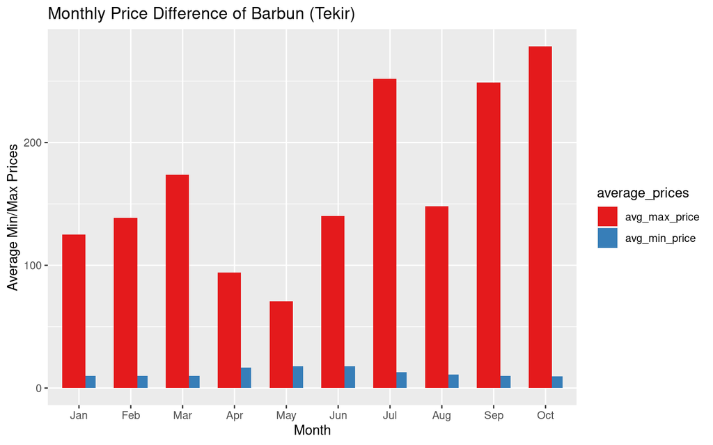

```r
barbun_tekir  <- barbun_monthly_avg_pivot %>%
  filter(product_name == "BARBUN (TEKİR)")

ggplot(barbun_tekir, aes(month, values, fill=average_prices)) +
  geom_col(position = position_dodge(width = 0.4)) +
  scale_fill_brewer(palette = "Set1") +
  labs(x= "Month",
       y = "Average Min/Max Prices",
       title = "Monthly Price Difference of Barbun (Tekir)")
```

## Barbun (Kaya)

From January to October, minimum and maximum price difference of Barbun (Kaya) is high in almost all months. However, the difference in Barbun (Tekir) is more than Barbun (Kaya).

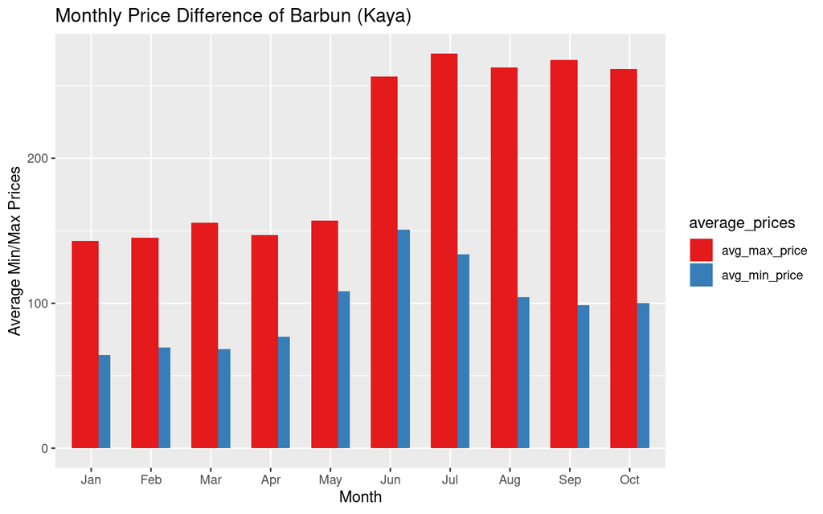

```r
barbun_kaya <- barbun_monthly_avg_pivot %>%
  filter(product_name == "BARBUN(KAYA)")

ggplot(barbun_kaya, aes(month, values, fill=average_prices)) +
  geom_col(position = position_dodge(width = 0.4)) +
  scale_fill_brewer(palette = "Set1") +
  labs(x= "Month",
       y = "Average Min/Max Prices",
       title = "Monthly Price Difference of Barbun (Kaya)")
```

## Barbun (Donuk)

We do not have information of all months for the Barbun (Donuk), we only have May and June data. It is clearly seen in the graph below, there is no price difference in both months for Barbun (Donuk).

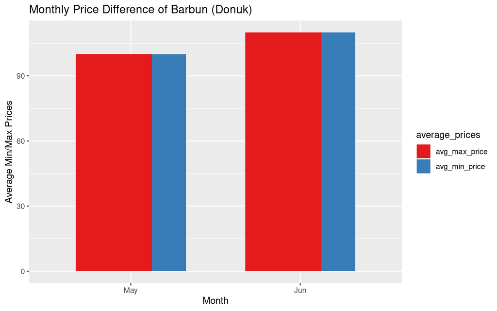

```r
barbun_donuk <- barbun_monthly_avg_pivot %>%
  filter(product_name == "BARBUN(DONUK)")

ggplot(barbun_donuk, aes(month, values, fill=average_prices)) +
  geom_col(position = position_dodge(width = 0.4)) +
  scale_fill_brewer(palette = "Set1") +
  labs(x= "Month",
       y = "Average Min/Max Prices",
       title = "Monthly Price Difference of Barbun (Donuk)")
```

## Barbun Kaya (Donuk)

We do not have information of all months for the Barbun Kaya (Donuk) as well. What we have is only July and August data. There is a price difference for Barbun Kaya (Donuk) in July unlike August.

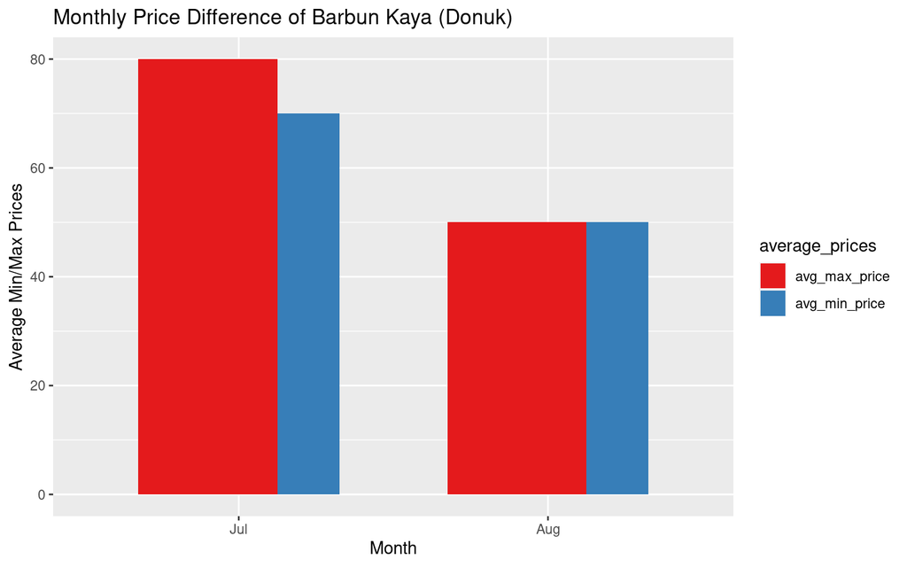

```r
barbun_kaya_donuk <- barbun_monthly_avg_pivot %>%
  filter(product_name == "BARBUN KAYA (DONUK)")

ggplot(barbun_kaya_donuk, aes(month, values, fill=average_prices)) +
  geom_col(position = position_dodge(width = 0.4)) +
  scale_fill_brewer(palette = "Set1") +
  labs(x= "Month",
       y = "Average Min/Max Prices",
       title = "Monthly Price Difference of Barbun Kaya (Donuk)")
```